# Data Cleaning Lab Key

# Data used

Bike Lanes Dataset: BikeBaltimore is the Department of Transportation’s bike program. The data is from http://data.baltimorecity.gov/Transportation/Bike-Lanes/xzfj-gyms

You can Download as a CSV in your current working directory. Note its also available at: http://jhudatascience.org/intro_to_R_class/data/Bike_Lanes.csv

```r
library(readr)
library(tidyverse)
library(dplyr)
library(lubridate)
library(jhur)
library(tidyverse)
library(broom)
library(naniar)

bike <- jhur::read_bike()
```

# Part 1

1. Use the `is.na()` and `any()` functions to check if the bike `dateInstalled` variable has any `NA` values.

```r
any(is.na(bike$dateInstalled))
```

```
## [1] FALSE
```

```r
#or
bike %>% pull(dateInstalled) %>% is.na() %>% any()
```

```
## [1] FALSE
```

2. Filter rows of bike that are NOT missing using `drop_na` for the `route` variable, assign this to the object `have_route.`

```r
bike %>%  drop_na(route)
```

```
## # A tibble: 362 × 9
##    subType name    block    type   numLanes project   route length dateInstalled
##    <chr>   <chr>   <chr>    <chr>     <dbl> <chr>     <chr>  <dbl>         <dbl>
##  1 <NA>    <NA>    <NA>     SIDEP…        1 <NA>      NORT… 1025.           2010
##  2 STRALY  WINSTO… 1200 BL… SIGNE…        2 COLLEGET… COLL…  148.           2007
##  3 STRALY  WINSTO… 1200 BL… SIGNE…        2 COLLEGET… COLL…  366.           2007
##  4 STRALY  WINSTO… 1200 BL… SIGNE…        2 COLLEGET… COLL…  262.           2007
##  5 STRPRD  <NA>    <NA>     SIGNE…        1 COLLEGET… COLL…   49.3          2007
##  6 STRPRD  <NA>    <NA>     SIGNE…        1 COLLEGET… COLL…   70.0          2007
##  7 STRPRD  <NA>    <NA>     SIGNE…        1 COLLEGET… COLL…  765.           2007
##  8 STRPRD  <NA>    <NA>     SIGNE…        2 COLLEGET… COLL…  170.           2007
##  9 STRPRD  <NA>    <NA>     SIGNE…        2 COLLEGET… COLL… 1724.           2007
## 10 STRPRD  ALBEMA… 100 BLK… SIGNE…        1 SOUTHEAS… LITT…  250.           2011
## # … with 352 more rows
```

3. Use `naniar` to make a visual of the amount of data missing for each variable of `bike` (use `naniar::gg_miss_var()`). Check out more about this package here: https://www.njtierney.com/post/2018/06/12/naniar-on-cran/

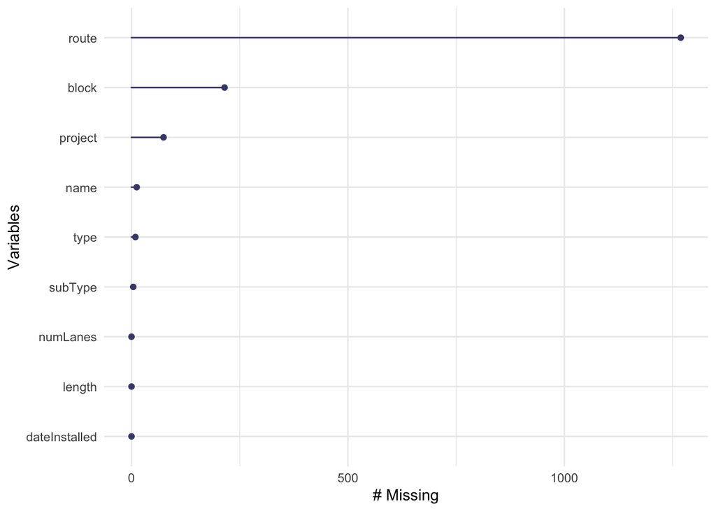

```r
naniar::gg_miss_var(bike)
```

4. What is the percent complete for `subType` of `bike` ? Hint: use another `naniar` function.

```r
naniar::pct_complete(bike$subType) #this or..
```

```
## [1] 99.75475
```

```r
pull(bike, subType) %>% pct_complete() # this
```

```
## [1] 99.75475
```

# Part 2

**New Data set** Now imagine we work in a clinic and we are trying to understand more about blood types of patients.

Let’s say we the data like so:

```r
BloodType <- tibble(gender =
                    c("M", "Male", "Female", "F", "M",
                      "Male", "Other", "M", "F", "Other",
                      "F", "Male", NA, "Male", "Female"),
                    type = c("A.-", "AB.+", "O.-", "O.+", "AB.-",
                               "B.+", "B.-", "o.-", "O.+", "A.-",
                              "A.+", "O.-", "B.-", "o.+", "AB.-"),
                    infection = c("Yes", "No", "Yes", "No", "No",
                                  "No", "Yes", "No", "Yes", "No",
                                  "No", "Yes", "Yes", "Yes", "NotSure"))

BloodType
```

```
## # A tibble: 15 × 3
##    gender type  infection
##    <chr>  <chr> <chr>
##  1 M      A.-   Yes
##  2 Male   AB.+  No
##  3 Female O.-   Yes
##  4 F      O.+   No
##  5 M      AB.-  No
##  6 Male   B.+   No
##  7 Other  B.-   Yes
##  8 M      o.-   No
##  9 F      O.+   Yes
## 10 Other  A.-   No
## 11 F      A.+   No
## 12 Male   O.-   Yes
## 13 <NA>   B.-   Yes
## 14 Male   o.+   Yes
## 15 Female AB.-  NotSure
```

There are some issues with this data that we need to figure out!

1. Determine how many NA values there are for gender.

```r
count(BloodType, gender)
```

```
## # A tibble: 6 × 2
##   gender     n
##   <chr>  <int>
## 1 F          3
## 2 Female     2
## 3 M          3
## 4 Male       4
## 5 Other      2
## 6 <NA>       1
```

```r
sum(is.na(pull(BloodType, gender)))
```

```
## [1] 1
```

```r
BloodType %>% pull(gender) %>% is.na() %>% sum()
```

```
## [1] 1
```

2. Recode the `gender` variable of the `BloodType` data so that it is consistent. Use `case_when()`.

```r
BloodType <- BloodType %>%
  mutate(gender = case_when(gender %in% c("M", "m", "Male") ~ "Male",
                            gender %in% c("F", "female", "Female") ~ "Female",
                            gender %in% c("Other") ~ "Other"))

count(BloodType, gender)
```

```
## # A tibble: 4 × 2
##   gender     n
##   <chr>  <int>
## 1 Female     5
## 2 Male       7
## 3 Other      2
## 4 <NA>       1
```

Check to see how many values `gender` has for each category (hint: use `count`). It’s good practice to regularly check your data throughout the data wrangling process.

```r
BloodType %>% count(gender)
```

```
## # A tibble: 4 × 2
##   gender     n
##   <chr>  <int>
## 1 Female     5
## 2 Male       7
## 3 Other      2
## 4 <NA>       1
```

4. Recode the `type` variable of the `BloodType` data to be consistent. Use `recode`.

```r
BloodType <- BloodType %>%
  mutate(type = recode(type, "o.-" = "O.-",
                             "o.+" = "O.+"))
BloodType
```

```
## # A tibble: 15 × 3
##    gender type  infection
##    <chr>  <chr> <chr>
##  1 Male   A.-   Yes
##  2 Male   AB.+  No
##  3 Female O.-   Yes
##  4 Female O.+   No
##  5 Male   AB.-  No
##  6 Male   B.+   No
##  7 Other  B.-   Yes
##  8 Male   O.-   No
##  9 Female O.+   Yes
## 10 Other  A.-   No
## 11 Female A.+   No
## 12 Male   O.-   Yes
## 13 <NA>   B.-   Yes
## 14 Male   O.+   Yes
## 15 Female AB.-  NotSure
```

5. Check to see that `type` only has these possible values: “A.-”,“A.+”, “AB.-”, “AB.+”, “B-”,“B+”, “O.-”, “O.+”

```r
BloodType %>% pull(type) %>% table(useNA = "ifany")
```

```
## .
##  A.-  A.+ AB.- AB.+  B.-  B.+  O.-  O.+
##    2    1    2    1    2    1    3    3
```

```r
 #or
BloodType %>% count(type)
```

```
## # A tibble: 8 × 2
##   type      n
##   <chr> <int>
## 1 A.-       2
## 2 A.+       1
## 3 AB.-      2
## 4 AB.+      1
## 5 B.-       2
## 6 B.+       1
## 7 O.-       3
## 8 O.+       3
```

6. Make a new tibble of `BloodType` called `Bloodtype_split` that splits the `type` variable into two called `blood_type` and `Rhfactor`. Note: periods are special characters that generally are interpreted as wild cards thus we need `\\` to tell R that we want it to be interpreted as a period.

```r
##______________ <- ________ %>%
#________(____, ____ = c(__________, __________), sep = "\\.")

BloodType_split  <- BloodType %>% separate(type, into = c("blood_type", "Rhfactor"), sep = "\\.")
```

Bonus: How many observations are there for each `Rhfactor`:

```r
table(BloodType_split$Rhfactor) # base R
```

```
##
## - +
## 9 6
```

```r
count(BloodType_split,Rhfactor)
```

```
## # A tibble: 2 × 2
##   Rhfactor     n
##   <chr>    <int>
## 1 -            9
## 2 +            6
```

Bonus: Filtering for patients with type O, how many had the infection?

```r
BloodType_split %>%
  filter(blood_type == "O") %>%
  count(infection)
```

```
## # A tibble: 2 × 2
##   infection     n
##   <chr>     <int>
## 1 No            2
## 2 Yes           4
```